# Climate Risk: A New Era for the South Pacific

Juan J. Ortiz Ortega

On March 13th 2015, an ominous sensation swept over the shores of Port Vila. Hotels, schools and roads were deserted. More than 2000 people were sheltering in evacuation centres. Disaster was looming on the horizon.

That evening, just before midnight, **Pam**, a category five cyclone, struck Vanuatu’s capital with extremely destructive force. Winds reaching 250kmph ripped off metal roofs from houses and schools; communications and power infrastructure were destroyed or heavily damaged; crops were wiped out and food stocks blown into debris. The devastation was unprecedented, affecting 188,000 people (over half the population), with up to 90% of buildings damaged or destroyed. Total estimated economic losses reached $449 million (roughly 64% of Vanuatu’s GDP).

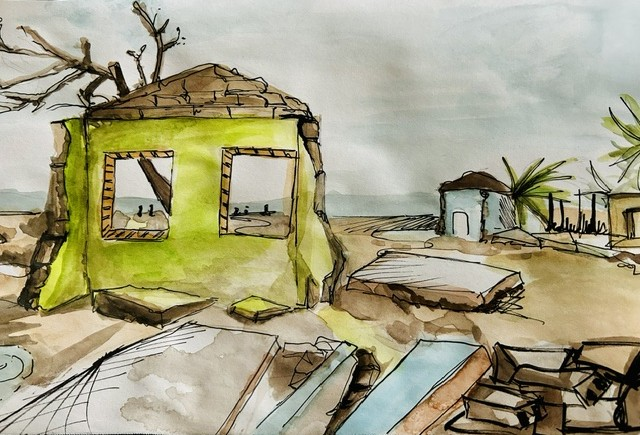

Cyclone Pam Aftermath

By and large, the Pacific Region is one of the most vulnerable regions in the world. Perennial friction between the Australian and Pacific tectonic plates trigger earthquakes and volcanic activity; sometimes resulting in massive tsunamis. Shifts in ocean currents and weather patterns such as El Niño generate cyclones and droughts. For people living in this vast region, such natural disasters are nothing new.

**What has changed?**

Statistics from the Pacific Data Hub show that, during the last decade, disasters affecting large proportions of the population across **Melanesia** and **Micronesia** have become more frequent. Tuvalu and Tonga in Polynesia reflect this new pattern too. The arrival of Cyclone Pam in 2015 seemed to mark the beginning of a new era of more frequent and devastating disasters. This trend poses a growing challenge, as regional economies struggle to rebuild and recover .

Only a year after Pam’s tragic appearance, **Winston** emerged. Back then, the fiercest tropical storm ever recorded in the Southern Hemisphere. Its trajectory was unusual; it followed a big counter-clockwise loop to the east of Fiji, accumulating strength before striking Viti Levu, Fiji’s largest island. The human and economic toll were catastrophic: more than half a million people were affected and economic losses reached 10% of GDP.

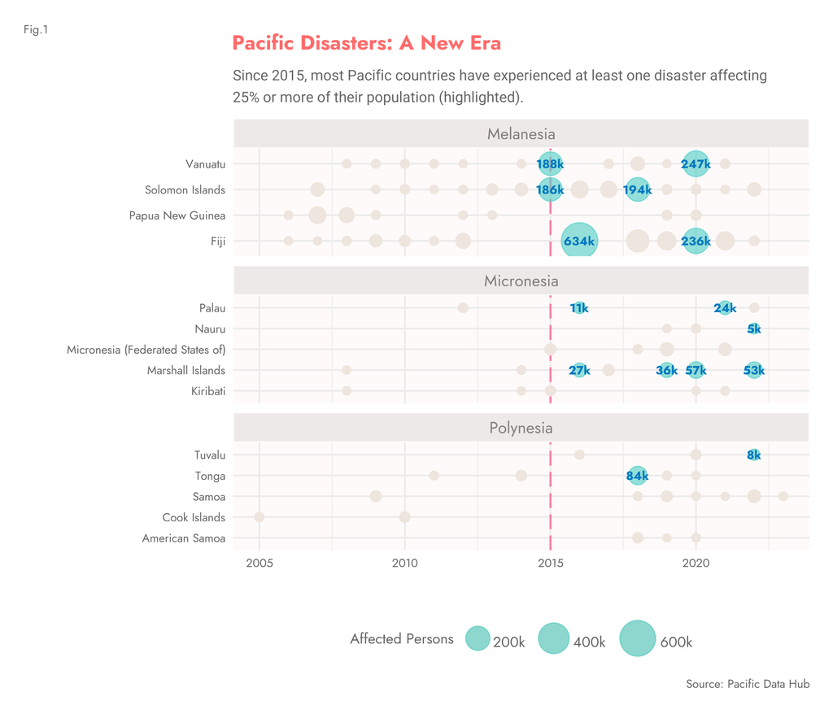

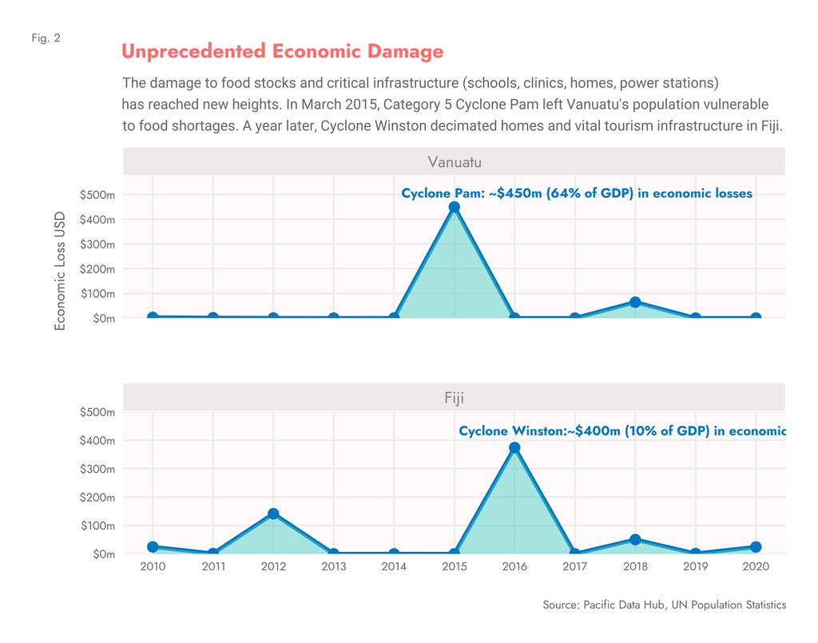

According to experts, “exceptionally warm” ocean temperatures above average, driven by El Niño and climate change, allowed Winston to intensify quickly and maintain its Category 5-level strength.

People in the Pacific are familiar with El Niño - a recurring climate pattern driven by shifts in the winds above the eastern Pacific. It delivers heavy rains in some places, droughts and heatwaves in others. Those weather effects ripple across the globe. The strength of any particular El Niño is measured by how much sea temperatures rise above average. The 2015-2016 edition was exceptional; nurturing strong tropical storms such as Winston. Over time, Pacific island countries have adapted to its impacts.

However, the data reveals another important milestone reached in 2015. For years, sea temperatures in the South Pacific have been rising steadily due to climate change and a warming planet. But in 2015, near the island of Kiribati, the first temperature anomaly > 1°C was recorded. Since then, four more anomalies have hit that threshold.

Although climate change and El Niño are not associated with each other, they amplify each other’s effects. The upshot for people living in the South Pacific is warmer sea temperatures and a greater risk of cyclones like Pam and Winston; high-impact disasters that can upend the lives of so many people and bring unprecedented damage on the economies that sustain them.

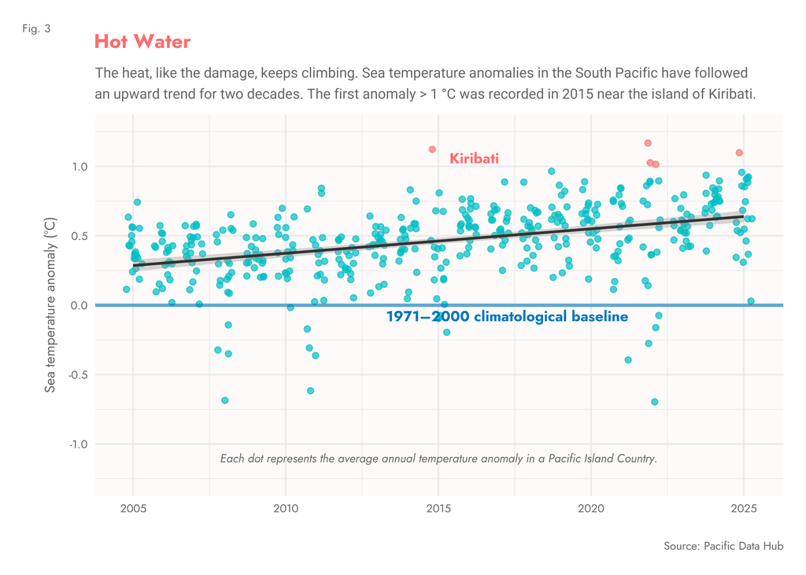

The message is clear: **climate change is the single greatest threat to the livelihoods, security and well-being of the peoples of the Pacific**. How can the Pacific South prepare for this new era?

*Pacific Data Viz Challenge 2026*

*Source Data:*

*Pacific Data Hub*

*- Number of directly affected persons attributed to disasters*

*- Direct disaster economic loss, average annual loss*

*- Climate Change Indicators: Sea Surface Temperature anomalies, Celsius*

*United Nations Population Statistics*

*References:*

- Asian Development Bank. 01 May 2019. [*The Pacific Islands: Building Resilience to Natural Disasters*.](https://www.adb.org/results/pacific-islands-building-resilience-natural-disasters).
- Humanitarian Action. November 2022, [*Pacific Islands.*](https://humanitarianaction.info/article/pacific-islands)
- Australia Government, Department of Foreign Affairs and Trade Crisis Hub. [*Tropical Cyclone Harold.*](https://www.dfat.gov.au/crisis-hub/tropical-cyclone-harold).
- The Guardian. 09 Apr 2020. [*It’s All Gone: Cyclone Harold cuts a deadly path through Vanuatu*.](https://www.theguardian.com/world/2020/apr/10/its-all-gone-cyclone-harold-cuts-a-deadly-path-through-vanuatu).
- Climate Signals. [*Tropical Cyclone Winston*.](https://www.climatesignals.org/events/cyclone-winston-2016#more).
- Relief Web. 04 April 2015 [*End of Mission Report: United Nations Disaster Assessment & Coordination Team (UNDAC) Tropical Cyclone Pam Vanuatu*.](https://reliefweb.int/report/vanuatu/end-mission-report-united-nations-disaster-assessment-coordination-team-undac).